# R Notebook sandbox: Assignment “Datasets” (10 points) Revisited

Jessica Smith

9/19/2020

```r
library(devtools);
my.source = 'local';
local.path = "C:\\Users\\jsmit\\Desktop\\WSU\\DataAnalytics\\STAT419\\WSU_STATS419_FALL2020";
local.data.path = "R:/WSU_STATS419_FALL2020/";
#setwd(local.path)
knitr::opts_knit$set(root.dir = local.path)
source( paste0(local.path,"\\functions\\libraries.R"), local=T );
#install_github("MonteShaffer/humanVerseWSU/humanVerseWSU");
library(humanVerseWSU); # if your functions have the same name as the humanVerseWSU functions, there may be a collision ...  order of sourcing/library (which comes first, second, third, etc.) matters.
```

# 1 Matrix

Create the “rotate matrix” functions as described in lectures. Apply to the example “myMatrix”.

```r
source( paste0(local.path,"/functions/functions-matrix.R"), local=T );


myMatrix = matrix ( c (
                                            1, 0, 2,
                                            0, 3, 0,
                                            4, 0, 5
                                            ), nrow=3, byrow=T);

# dput(myMatrix); # useful
```

```r
humanVerseWSU::transposeMatrix(myMatrix);
```

```
##      [,1] [,2] [,3]
## [1,]    1    0    4
## [2,]    0    3    0
## [3,]    2    0    5
```

```r
rotateMatrix90(myMatrix);  # clockwise ...
```

```
##      [,1] [,2] [,3]
## [1,]    4    0    1
## [2,]    0    3    0
## [3,]    5    0    2
```

```r
rotateMatrix180(myMatrix);
```

```
##      [,1] [,2] [,3]
## [1,]    5    0    4
## [2,]    0    3    0
## [3,]    2    0    1
```

```r
rotateMatrix270(myMatrix);
```

```
##      [,1] [,2] [,3]
## [1,]    2    0    5
## [2,]    0    3    0
## [3,]    1    0    4
```

```r
# rotateMatrix(mat,a) ### one function using a switch statement ...
```

# 2 IRIS

Recreate the graphic for the IRIS Data Set using R. Same titles, same scales, same colors. See:

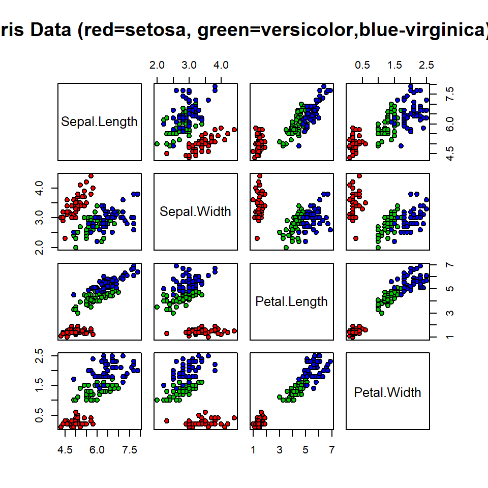

```r
data(iris)
pairs(iris[1:4], main = "Iris Data (red=setosa, green=versicolor,blue-virginica)",
      pch = 21, bg = c("red", "green3", "blue")[unclass(iris$Species)])
```

Sentences: [Right 2-3 sentences concisely defining the IRIS Data Set. Maybe search KAGGLE for a nice template. Be certain the final writeup are your own sentences (make certain you modify what you find, make it your own, but also cite where you got your ideas from). NOTE: Watch the video, Figure 8 has a +5 EASTER EGG.]

The well known iris data set contains 50 measurements, each from 3 species of iris flower. The metrics include petal length, petal width, sepal length, and sepal width. The dataset is commonly used to teach clustering analysis and to demonstrate basic programmatic functionality. (Kaggle, 2020)

# 3 Personality

## 3.1 Cleanup RAW

Import “personality-raw.txt” into R. Remove the V00 column. Create two new columns from the current column “date_test”: year and week. Stack Overflow may help: https://stackoverflow.com/questions/22439540/how-to-get-week-numbers-from-dates … Sort the new data frame by YEAR, WEEK so the newest tests are first … The newest tests (e.g., 2020 or 2019) are at the top of the data frame. Then remove duplicates using the unique function based on the column “md5_email”. Save the data frame in the same “pipe-delimited format” ( | is a pipe ) with the headers. You will keep the new data frame as “personality-clean.txt” for future work (you will not upload it at this time). In the homework, for this tasks, report how many records your raw dataset had and how many records your clean dataset has.

```r
# working directory is good-to-go

myFile = paste0(local.path,"/datasets/personality/personality-raw.txt");

#read in the data
personality = read.table(myFile, header = TRUE, sep = "|", dec = ".")

#remove unwanted column
personality = subset(personality, select = -c(V00))

#create two columns from date_test, one year and one week
temp = strsplit(as.character(personality$date_test), " ")
personality$date = matrix(unlist(temp), ncol=2, byrow=TRUE)[,1]
personality$year = format(as.Date(personality$date, "%m/%d/%Y"), format="%Y")
personality$week = format(as.Date(personality$date, "%m/%d/%Y"), format= "%W")
personality = subset(personality, select = -c(date, date_test))
library(dplyr)
personality = personality  %>% select(md5_email, year, week, everything())

#Sort the new data frame by YEAR, WEEK so the newest tests are at the top of the df
personality = personality[order(-(as.numeric(personality$year)), -(as.numeric(personality$week))), ]

#remove duplicates using the unique function based on the column "md5_email"
unique = unique(personality$md5_email)
rows = match(unique, personality$md5_email)

unique_personalities = personality[rows,]

#Save the data frame in the "pipe-delimited format" as "personality-clean.txt"
write.table(unique_personalities,"personality-clean.txt",sep="|", row.names=FALSE)

cat("The raw dataset contains ",nrow(personality),
" records, and the cleaned dataset has ", nrow(unique_personalities),".", sep = "")
```

```
## The raw dataset contains 838 records, and the cleaned dataset has 678.
```

# 4 Variance and Z-scores

Write functions for doSummary and sampleVariance and doMode … test these functions in your homework on the “monte.shaffer@gmail.com” record from the clean dataset. Report your findings. For this “monte.shaffer@gmail.com” record, also create z-scores. Plot(x,y) where x is the raw scores for “monte.shaffer@gmail.com” and y is the z-scores from those raw scores. Include the plot in your assignment, and write 2 sentences describing what pattern you are seeing and why this pattern is present.

```r
x.norm = rnorm(100,0,1);
s.norm = doStatsSummary ( x.norm );
str(s.norm);  # mode is pretty meaningless on this data
```

```
## List of 32
##  $ length           : int 100
##  $ length.na        : int 0
##  $ length.good      : int 100
##  $ mean             : num 0.0945
##  $ mean.trim.05     : num 0.11
##  $ mean.trim.20     : num 0.0818
##  $ median           : num 0.133
##  $ MAD              : num 1
##  $ IQR              : num 1.26
##  $ quartiles        : Named num [1:3] -0.622 0.133 0.641
##   ..- attr(*, "names")= chr [1:3] "25%" "50%" "75%"
##  $ deciles          : Named num [1:9] -1.1 -0.781 -0.408 -0.161 0.133 ...
##   ..- attr(*, "names")= chr [1:9] "10%" "20%" "30%" "40%" ...
##  $ centiles         : Named num [1:99] -2.64 -2.62 -2.3 -2.18 -2.07 ...
##   ..- attr(*, "names")= chr [1:99] "1%" "2%" "3%" "4%" ...
##  $ median.weighted  : num 1
##  $ MAD.weighted     : num 0.133
##  $ max              : num 2.79
##  $ min              : num -2.7
##  $ range            : num 5.49
##  $ xlim             : num [1:2] -2.7 2.79
##  $ max.idx          : num 86
##  $ min.idx          : num 95
##  $ freq.max         : num [1:100] -2.7 -2.64 -2.62 -2.29 -2.18 ...
##  $ mode             : num [1:100] -2.7 -2.64 -2.62 -2.29 -2.18 ...
##  $ which.min.freq   : num [1:100] -2.7 -2.64 -2.62 -2.29 -2.18 ...
##  $ ylim             : int [1:2] 1 1
##  $ sd               : num 1.17
##  $ var              : num 1.36
##  $ var.naive        :List of 3
##   ..$ x.bar: num 0.0945
##   ..$ s.var: num 1.36
##   ..$ s.sd : num 1.17
##  $ var.2step        :List of 3
##   ..$ x.bar: num 0.0945
##   ..$ s.var: num 1.36
##   ..$ s.sd : num 1.17
##  $ shapiro          :List of 4
##   ..$ statistic: Named num 0.981
##   .. ..- attr(*, "names")= chr "W"
##   ..$ p.value  : num 0.156
##   ..$ method   : chr "Shapiro-Wilk normality test"
##   ..$ data.name: chr "xx"
##   ..- attr(*, "class")= chr "htest"
##  $ shapiro.is.normal:List of 3
##   ..$ 0.10: logi TRUE
##   ..$ 0.05: logi TRUE
##   ..$ 0.01: logi TRUE
##  $ outliers.z       :'data.frame':   0 obs. of  2 variables:
##   ..$ value    : Factor w/ 0 levels:
##   ..$ direction: Factor w/ 0 levels:
##  $ outliers.IQR     :'data.frame':   5 obs. of  3 variables:
##   ..$ value    : Factor w/ 5 levels "-2.62174232759597",..: 2 1 3 4 5
##   ..$ fence    : Factor w/ 1 level "inner": 1 1 1 1 1
##   ..$ direction: Factor w/ 2 levels "lower","upper": 1 1 1 2 2
```

```r
x.unif = runif(100,0,1);
s.unif = doStatsSummary ( x.unif );
str(s.unif);  # mode is pretty meaningless on this data
```

```
## List of 32
##  $ length           : int 100
##  $ length.na        : int 0
##  $ length.good      : int 100
##  $ mean             : num 0.489
##  $ mean.trim.05     : num 0.487
##  $ mean.trim.20     : num 0.475
##  $ median           : num 0.444
##  $ MAD              : num 0.324
##  $ IQR              : num 0.441
##  $ quartiles        : Named num [1:3] 0.273 0.444 0.714
##   ..- attr(*, "names")= chr [1:3] "25%" "50%" "75%"
##  $ deciles          : Named num [1:9] 0.135 0.222 0.32 0.391 0.444 ...
##   ..- attr(*, "names")= chr [1:9] "10%" "20%" "30%" "40%" ...
##  $ centiles         : Named num [1:99] 0.0351 0.0416 0.0468 0.0473 0.0497 ...
##   ..- attr(*, "names")= chr [1:99] "1%" "2%" "3%" "4%" ...
##  $ median.weighted  : num 0.324
##  $ MAD.weighted     : num 0.444
##  $ max              : num 0.992
##  $ min              : num 0.0204
##  $ range            : num 0.971
##  $ xlim             : num [1:2] 0.0204 0.9917
##  $ max.idx          : num 41
##  $ min.idx          : num 94
##  $ freq.max         : num [1:100] 0.0204 0.0353 0.0417 0.047 0.0473 ...
##  $ mode             : num [1:100] 0.0204 0.0353 0.0417 0.047 0.0473 ...
##  $ which.min.freq   : num [1:100] 0.0204 0.0353 0.0417 0.047 0.0473 ...
##  $ ylim             : int [1:2] 1 1
##  $ sd               : num 0.278
##  $ var              : num 0.0772
##  $ var.naive        :List of 3
##   ..$ x.bar: num 0.489
##   ..$ s.var: num 0.0772
##   ..$ s.sd : num 0.278
##  $ var.2step        :List of 3
##   ..$ x.bar: num 0.489
##   ..$ s.var: num 0.0772
##   ..$ s.sd : num 0.278
##  $ shapiro          :List of 4
##   ..$ statistic: Named num 0.959
##   .. ..- attr(*, "names")= chr "W"
##   ..$ p.value  : num 0.00341
##   ..$ method   : chr "Shapiro-Wilk normality test"
##   ..$ data.name: chr "xx"
##   ..- attr(*, "class")= chr "htest"
##  $ shapiro.is.normal:List of 3
##   ..$ 0.10: logi FALSE
##   ..$ 0.05: logi FALSE
##   ..$ 0.01: logi FALSE
##  $ outliers.z       :'data.frame':   0 obs. of  2 variables:
##   ..$ value    : Factor w/ 0 levels:
##   ..$ direction: Factor w/ 0 levels:
##  $ outliers.IQR     :'data.frame':   0 obs. of  3 variables:
##   ..$ value    : Factor w/ 0 levels:
##   ..$ fence    : Factor w/ 0 levels:
##   ..$ direction: Factor w/ 0 levels:
```

```r
v2.norm = doSampleVariance(x.norm, "two-pass");
v2b.norm = doSampleVariance(x.norm);  # default value is "two-pass" in the function
v2c.norm = doSampleVariance(x.norm, "garblideljd=-gook"); # if logic defaults to "two-pass"

unlist(v2.norm);
```

```
##          sumXs sumDiffSquared       variance
##       9.448631     134.929412       1.362923
```

```r
unlist(v2b.norm);
```

```
##          sumXs sumDiffSquared       variance
##       9.448631     134.929412       1.362923
```

```r
unlist(v2c.norm);
```

```
##          sumXs sumDiffSquared       variance
##       9.448631     134.929412       1.362923
```